# CA House Price Prediction

### LASSO Calculate and Collect Metrics

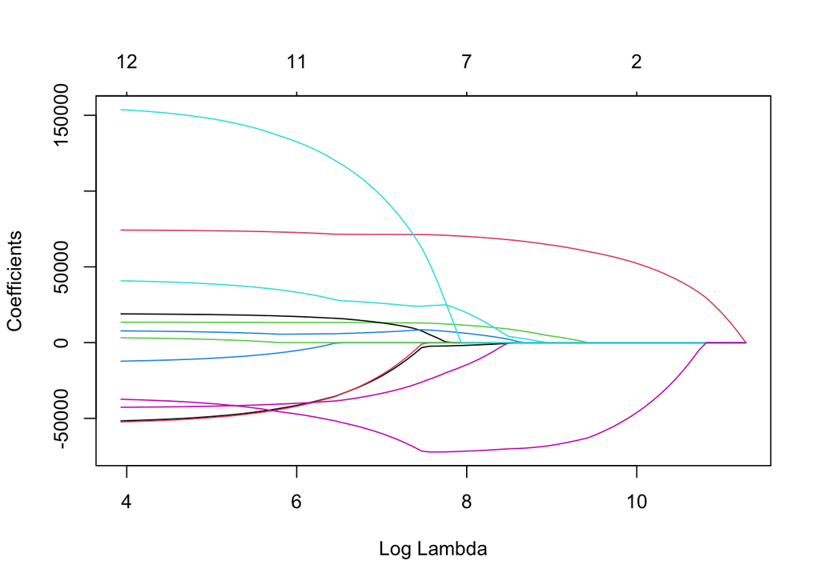

```r
# plotting LASSO lambda
plot(lasso_fit %>%
       extract_fit_parsnip() %>%
       pluck('fit'), # way to get the original glmnet output
     xvar = "lambda")
```

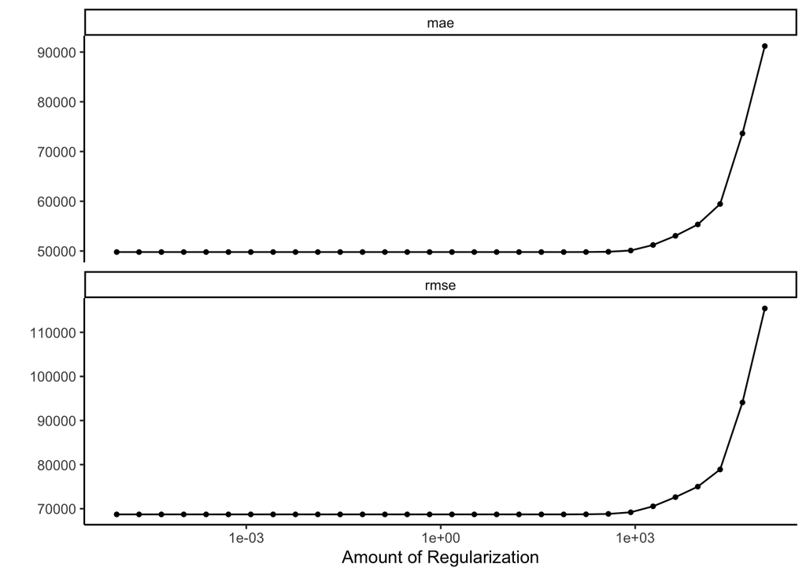

```r
# Visualize LASSO Metrics from Tuning
autoplot(tune_res) + theme_classic()
```

```r
# Summarize LASSO CV Metrics
collect_metrics(tune_res) %>%
  filter(.metric == 'rmse') %>% # or choose mae
  select(penalty, rmse = mean)
```

```
## # A tibble: 30 × 2
##      penalty   rmse
##        <dbl>  <dbl>
##  1 0.00001   68714.
##  2 0.0000221 68714.
##  3 0.0000489 68714.
##  4 0.000108  68714.
##  5 0.000240  68714.
##  6 0.000530  68714.
##  7 0.00117   68714.
##  8 0.00259   68714.
##  9 0.00574   68714.
## 10 0.0127    68714.
## # … with 20 more rows
```

```r
# choose penalty value based on lowest mae or rmse
best_penalty <- select_best(tune_res, metric = 'rmse')
best_penalty
```

```
## # A tibble: 1 × 2
##   penalty .config
##     <dbl> <chr>
## 1 0.00001 Preprocessor1_Model01
```

```r
# choose penalty value based on the largest penalty within 1 se of the lowest CV MAE
best_se_penalty <- select_by_one_std_err(tune_res, metric = 'mae', desc(penalty))


# Fit Final LASSO Models
final_wf <- finalize_workflow(lasso_wf, best_penalty) # incorporates penalty value to workflow
final_wf_se <- finalize_workflow(lasso_wf, best_se_penalty) # incorporates penalty value to workflow


final_fit <- fit(final_wf, data = housing)
final_fit_se <- fit(final_wf_se, data = housing)

tidy(final_fit)
```

```
## # A tibble: 13 × 3
##    term               estimate penalty
##    <chr>                 <dbl>   <dbl>
##  1 (Intercept)         216300. 0.00001
##  2 longitude           -51652. 0.00001
##  3 latitude            -52373. 0.00001
##  4 housing_median_age   13470. 0.00001
##  5 total_rooms         -12254. 0.00001
##  6 total_bedrooms       40829. 0.00001
##  7 population          -42678. 0.00001
##  8 households           18941. 0.00001
##  9 median_income        74278. 0.00001
## 10 ocean_proximity_X2    3193. 0.00001
## 11 ocean_proximity_X3    7731. 0.00001
## 12 ocean_proximity_X4  153748. 0.00001
## 13 ocean_proximity_X5  -37367. 0.00001
```

```r
tidy(final_fit_se)
```

```
## # A tibble: 13 × 3
##    term               estimate penalty
##    <chr>                 <dbl>   <dbl>
##  1 (Intercept)         223724.    853.
##  2 longitude           -28950.    853.
##  3 latitude            -28678.    853.
##  4 housing_median_age   13219.    853.
##  5 total_rooms              0     853.
##  6 total_bedrooms       26949.    853.
##  7 population          -36168.    853.
##  8 households           14685.    853.
##  9 median_income        71425.    853.
## 10 ocean_proximity_X2       0     853.
## 11 ocean_proximity_X3    6385.    853.
## 12 ocean_proximity_X4  109045.    853.
## 13 ocean_proximity_X5  -55699.    853.
```

- use estimate to talk abiout how changes in coefficient leads to changes in response variable

### LASSO Visualize residuals

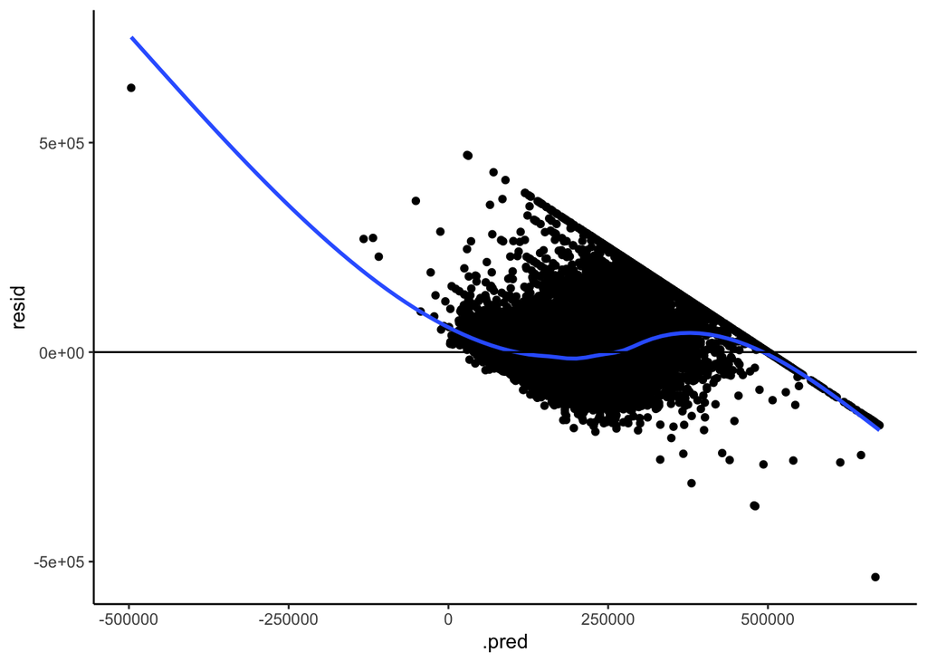

```r
lasso_mod_out <- final_fit_se %>%
    predict(new_data = housing) %>%
    bind_cols(housing) %>%
    mutate(resid = median_house_value - .pred)

lasso_mod_out %>%
  ggplot(aes(x = .pred, y = resid)) +
  geom_point() +
  geom_smooth(se = FALSE) +
  geom_hline(yintercept = 0) +
  theme_classic()
```

- there’s a straight line cuz of the cap at 500000 for housing value

$~$

C.Compare estimated test performance across the models. Which models(s) might you prefer?

- Using the measures calculated using the ordinary least squares. Also, using the average cross validated rmse model 1 performed the bed. The first model including all the variables is the best. This is also validated using the best lambda measure calculated using lasso.

$~$

D. Use residual plots to evaluate whether some quantitative predictors might be better modeled with nonlinear relationships.

$~$

E. Which variables do you think are the most important predictors of your quantitative outcome? Justify your answer. Do the methods you’ve applied reach consensus on which variables are most important? What insights are expected? Surprising?

- The most important predictor according to the lasso is median income. It survives the longest. Median income also has the lowest p value. This is not surprising as a higher income would suggest the neighboring household’s ability to purchase a more expensive home. Using p value population the relationship observed in population has the second lowest probability of being caused by random chance. All that’s being said, however, p value is not always the best indicator of which variables to include in the model.

### Summarize Investigations

Decide on an overall best model based on your investigations so far. To do this, make clear your analysis goals. Predictive accuracy? Interpretability? A combination of both?

- The model that contains all of the variables in the data set is the best model so far. Based on the fact that that model yielded the lowest CV test error rate, it seems like taking into account of house age, number of rooms, location, ocean proximity, total bedrooms, population, and income level of that block of houses is important to determine house value.
- The interpretability of our model is pretty staright forward, though we would like to find out if some individual variables could have more influence on house value and make predictions with that variable.

$~$ $~$

### Societal Impact

Are there any harms that may come from your analyses and/or how the data were collected? What cautions do you want to keep in mind when communicating your work?

- The variable `median_income` measures the median income for households within a block of houses. Since this variable seems to be the most persistent in our model, according to our LASSO results, this confirms the seriously large wage gap in the United States. Income affects one’s social status, health care access, and even house value. We could further infer from our preliminary analysis that income affects house value because it is more likely that those who have a higher income are not criminals. Where criminal activity is low, housing options there attracts more buyers — especially buyers of higher social status.
- The data was derived from Aurélien Géron’s book ‘Hands-On Machine learning with Scikit-Learn and TensorFlow’. It contains the 1990 California census information, specifically on housing. We don’t suspect that the way in which the data was collected is harmful. But we do need to acknowledge that those who did respond to census letters are probably those who have a mailing address and those who are middle to higher income groups. Back in the days, I don’t think there census surveys are delivered eletronically and therefore data collection must have had missed people who do not have a mailing address or P.O. box. Additionally, people who are middle to higher income groups would more likely respond to the census because they can read and write English, they might be more informed about the purpose of a census survey, and they might just have more time to attend to a list of questions printed on multiple pages of paper. People who had lower income and probably had to work so many more hours just to meet ends and the census letter could be the last on their minds. And keep in mind that the data set is specifically on California housing, which is arguably one of the more wealthy and liberal states in the US.

## Project Work

2. **Accounting for nonlinearity**
   - Update your models to use natural splines for some of the quantitative predictors to account for non-linearity (these are GAMs).
     - I recommend using OLS engine to fit these final models.
     - You’ll need to update the recipe to include `step_ns()` for each quantitative predictor that you want to allow to be non-linear.
     - To determine number of knots (`deg_free`), I recommend fitting a smoothing spline and use `edf` to inform your choice.
   - Compare insights from variable importance analyses here and the corresponding results from the Investigation 1. Now after having accounted for nonlinearity, have the most relevant predictors changed?
     - Do you gain any insights from the GAM output plots (easily obtained from fitting smoothing splines) for each predictor?
   - Compare model performance between your GAM models that the models that assuming linearity.
     - How does test performance of the GAMs compare to other models you explored?
   - Don’t worry about KNN for now.
3. **Summarize investigations**
   - Decide on an overall best model based on your investigations so far. To do this, make clear your analysis goals. Predictive accuracy? Interpretability? A combination of both?
4. **Societal impact**
   - Are there any harms that may come from your analyses and/or how the data were collected?
   - What cautions do you want to keep in mind when communicating your work?